# Practice Code: Day 10

Author

Constantin Manuel Bosancianu

Published

August 9, 2019

# 1 Introduction

The code represents a slightly modified version of an analysis prepared by the authors of the `HSAR` package to demonstrate some of the features of their package. I am grateful to the authors for making the script available online.[^1]

<sup>1</sup> As of January 2022, the `HSAR` package is no longer hosted on CRAN. This means that you have to install the package manually, from the archived repository.

```r
library(pacman)
p_load(tidyverse, sf, spdep, spatialreg, ggthemes, broom, knitr,
       arm, broom.mixed, HLMdiag, DHARMa, foreign, ggrepel,
       kableExtra, magrittr, devtools)
```

```r
install_version("HSAR", version = "0.5.1", repos = "http://cran.us.r-project.org")
```

```r
library(HSAR)
```

# 2 Hierarchical spatial analysis

In light of the shorter nature of today’s course, this will also be a slightly shorter script than usual. We rely today on the functions available in the `HSAR` package, designed for hierarchical spatial analysis. One of the main benefits of relying on this package is that it contains autonomous functions to handle the estimation, with no need to install some additional software for Bayesian estimation, like **Stan**, **JAGS**, or **WinBUGS**.

## 2.1 Data

The data comes also from the package, and refers to land prices in Beijing (to keep the connection going with the first article in the mandatory reading list). Though some social science examples would have likely been more interesting, they are also typically of larger size in terms of data, which would have made estimation a bit more time consuming.

In our sample we have information on prices on land parcels leased to real estate developers in Beijing, between 2003 and 2009. After deleting some missing data, we have information on 1,117 parcels:

1. `obs`: unique ID for each land parcel;
2. `lnprice`: natural logarithm of the leasing price per square meter (in RMB, Chinese yuan);
3. `dsubway`: log distance from each parcel to nearest railway station (in meters);
4. `dele`: log distance from each parcel to nearest elementary school (in meters);
5. `dpark`: log distance from each parcel to nearest park area (in meters);
6. `lnarea`: natural logarithm of parcel size (in square meters);
7. `lndcbd`: natural logarithm of the distance of each parcel to the central business district in Beijing (in meters);
8. `year`: year when the parcel was leased, in unit increases starting from 0 (2003), 1 (2004), …;
9. `popden`: population density in each district in which the land parcel is situated (in 1000 persons per sq. kilometer units);
10. `crimerate`: number of serious crimes reported in each district, per 1000 persons;
11. `district.id`: the ID of the district where each parcel is located.

```r
data("landprice")

landprice %>%
  glimpse()
```

```
Rows: 1,117
Columns: 11
$ obs         <int> 190, 992, 189, 993, 969, 994, 968, 1001, 970, 990, 184, 99…
$ lnprice     <dbl> 7.16382, 7.45757, 5.57430, 7.12569, 6.81564, 7.48522, 7.61…
$ lnarea      <dbl> 11.58780, 9.20029, 10.27820, 7.97788, 5.81928, 7.78634, 8.…
$ lndcbd      <dbl> 9.93534, 9.84785, 9.94866, 9.84388, 9.91940, 9.84203, 9.91…
$ dsubway     <dbl> 7.14334, 7.78904, 6.83023, 7.81991, 7.64640, 7.83398, 7.64…
$ dpark       <dbl> 6.78243, 6.95662, 7.06579, 7.00792, 6.88254, 7.03089, 6.84…
$ dele        <dbl> 6.67827, 7.05138, 6.81916, 7.11267, 4.10025, 7.13981, 4.60…
$ popden      <dbl> 0.548966, 0.548966, 0.548966, 0.548966, 0.548966, 0.548966…
$ crimerate   <dbl> 10.75110, 10.75110, 10.75110, 10.75110, 10.75110, 10.75110…
$ district.id <int> 3, 3, 3, 3, 3, 3, 3, 3, 3, 5, 5, 5, 5, 5, 5, 5, 7, 7, 7, 8…
$ year        <int> 1, 0, 1, 0, 0, 0, 0, 0, 0, 0, 1, 0, 1, 0, 6, 0, 1, 3, 4, 0…
```

The data contains land parcels located in 111 districts across the city.

## 2.2 Data preparation

The first steps of the analysis will be to get a matrix of distances between geographical units, which could then be incorporated into the estimation. We would have to do this even if we analyzed individuals dispersed across a map, e.g. needing to calculate their distance to the nearest hospital, or police station.

To do this, we will need a specialized package for handling GIS data in `R`, as well as some shapefiles with the geographic units we are interested in. If working with individual-level data, then we would also need a data set with the coordinates of these individuals on the map.

In the case of the land price data, both these data sets are provided in the `HSAR` package.

```r
data("Beijingdistricts")
data("landSPDF")
```

```r
summary(Beijingdistricts)
```

```
Object of class SpatialPolygonsDataFrame
Coordinates:
        min       max
x  426987.3  467920.9
y 4403558.7 4443286.6
Is projected: TRUE
proj4string :
[+proj=tmerc +lat_0=0 +lon_0=117 +k=1 +x_0=500000 +y_0=0 +ellps=krass
+units=m +no_defs]
Data attributes:
       id
 Min.   :  2.00
 1st Qu.: 37.00
 Median : 66.00
 Mean   : 66.15
 3rd Qu.: 97.50
 Max.   :133.00
```

```r
landSPDF %>%
    glimpse()
```

```
Formal class 'SpatialPointsDataFrame' [package "sp"] with 5 slots
  ..@ data       :'data.frame': 1117 obs. of  2 variables:
  .. ..$ obs        : int [1:1117] 190 992 189 993 969 994 968 1001 970 990 ...
  .. ..$ district.id: num [1:1117] 3 3 3 3 3 3 3 3 3 5 ...
  ..@ coords.nrs : num(0)
  ..@ coords     : num [1:1117, 1:2] 430547 432164 430237 432240 431002 ...
  .. ..- attr(*, "dimnames")=List of 2
  ..@ bbox       : num [1:2, 1:2] 428553 4406815 463693 4440423
  .. ..- attr(*, "dimnames")=List of 2
  ..@ proj4string:Formal class 'CRS' [package "sp"] with 1 slot
```

What we have is a data set of spatial polygons (the contours of the districts), and a data set of points - most likely these are the centroids of the land parcels in question. Before being able to map them, I have to convert them into the format that the `sf` package can read.

```r
Beijingdistricts <- st_as_sf(Beijingdistricts)
landSPDF <- st_as_sf(landSPDF)
```

In recent years, `ggplot2` has been able to plot spatial data frames as well, with the help of the `geom_sf()` function.

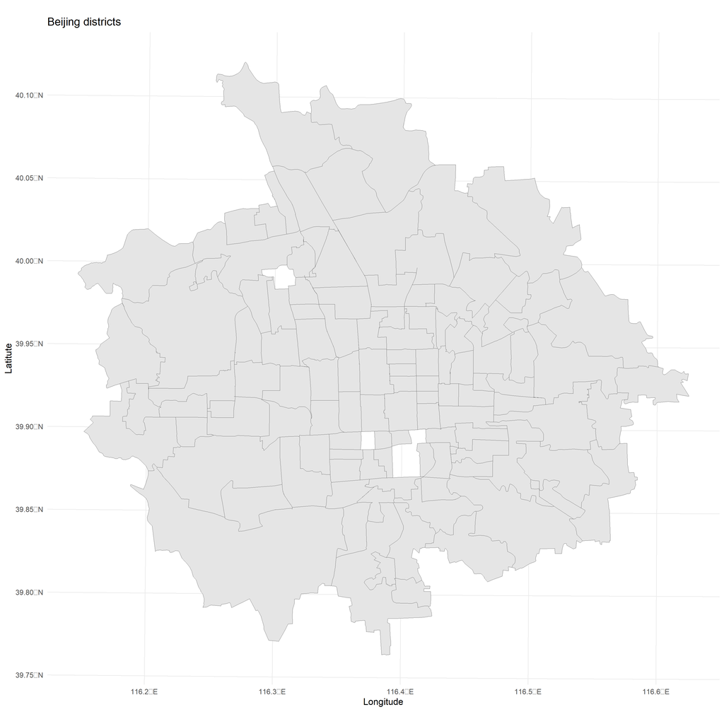

```r
ggplot(data = Beijingdistricts) +
    geom_sf() +
    theme_minimal() +
    labs(x = "Longitude",
         y = "Latitute",
         title = "Beijing districts")
```

Overlay the parcel location on the district map.

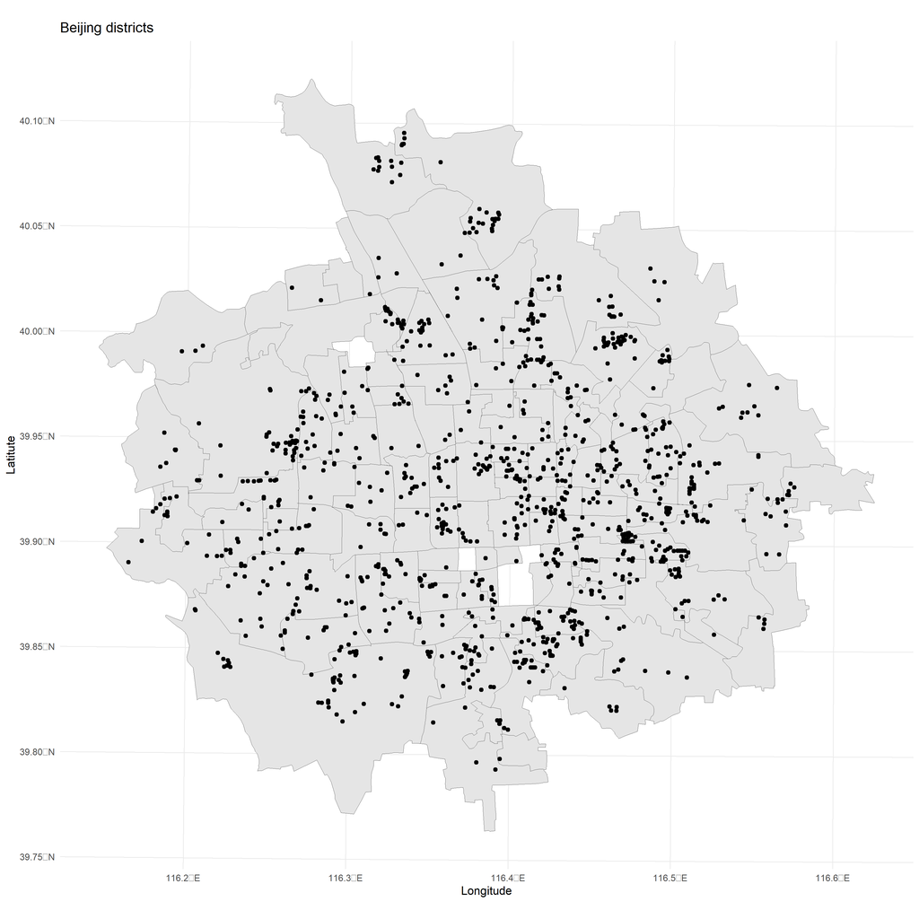

```r
ggplot(data = Beijingdistricts) +
    geom_sf() +
    geom_sf(data = landSPDF) +
    theme_minimal() +
    labs(x = "Longitude",
         y = "Latitute",
         title = "Beijing districts")
```

## 2.3 Random effects matrix

We start by defining the random effects matrix that our model will use. We first order parcels based on the district where they are located in.

```r
df_model <- landprice %>%
    arrange(district.id)

# Get the number of parcels in each district of the city
U_num <- df_model %>%
    group_by(district.id) %>%
    summarise(N = n()) %>%
    pull(N)

# Total number of districts (which will also be the number of random
# effects in the model)
U_total <- length(unique(df_model$district.id))
# IDs for the random effects
U_id <- rep(c(1:U_total), U_num)

# Sample size
n <- nrow(df_model)

# Matrix of location of parcels. Each parcel can uniquely be located in one
# district. Once a parcel has been placed in one district, the other cells on
# the same line will take the value of 0.
Delta <- matrix(0, nrow = n, ncol = U_total)

for(i in 1:U_total) {
  Delta[U_id == i, i] <- 1
}
rm(i)

# Constrain Delta to be a sparse numeric matrix (only a few cells of the entire
# matrix actually contain valid values).
Delta <- as(Delta, "dgCMatrix")
```

## 2.4 Spatial weights

We then extract the district level spatial weights. There’s no dedicated function for this in the `sf` package, so I switched to the `poly2nd()` function from the `spdep` package. The function essentially computes a list of the neighbors of each district.[^2] With this list of neighbors, the `nb2mat()` function produces the spatial weights matrix for the neighbors.[^3]

<sup>2</sup> I am using the “Queen’s rule”: so as long as there at least one point in common between the districts, this will consider them as neighbors.

<sup>3</sup> The `W` argument in the `nb2mat()` function means that the matrix is row standardized, which means all weights on a row sum up to 1.

```r
ngbrs <- poly2nb(Beijingdistricts,
                 queen = TRUE)

mat.list <- nb2mat(ngbrs,
                   style = "W")
# Again, convert it to a sparse matrix - this just saves memory for R.
M <- as(mat.list, "dgCMatrix")
```

We now have to compute the neighborhood matrix between parcels. The function `dnearneigh()` takes in the parcel data set (spatial points), and asks for a minimum and a maximum distance. Any parcel that is between 0 and 2.5 KM has been considered here a neighbor.[^4] This again produces a list of lists, where for each point on the map their neighbors are listed.

<sup>4</sup> No particular reason for why 2.5 was selected.

Based on this list of neighbors, and on the coordinates data for the parcels, the function `nbdists()` computes the Euclidean distance between a point and its neighbors.

```r
nb.25 <- dnearneigh(landSPDF, d1 = 0, d2 = 2500)
length(nb.25)
```

```
[1] 1117
```

```r
dist.25 <- nbdists(nb = nb.25,
                   coords = landSPDF$geometry)
```

We now have to come up with a function that assigns weights to these neighbors, depending on close they are to the actual observation.[^5] Try playing around with different values for x (between 0 and 2500), to see how the function behaves.

<sup>5</sup> This is called a *decay* function.

```r
dist.25 <- lapply(dist.25,
                  function(x) exp(-0.5 * (x / 2500)^1.5))

# We now finally have all the information to generate the spatial weights
# matrix for our parcels.
mat.25 <- nb2mat(nb.25,
                 glist = dist.25,
                 style = "W")

W <- as(mat.25, "dgCMatrix")
```

## 2.5 Basic model

We define the specification for the model, as well as get coefficients from an OLS, which we then use as priors in the Bayesian model.[^6]

<sup>6</sup> **Task**: For this specification, and the two below it, please center the predictors, and then re-estimate the model.

```r
# Formula for model
mod.form.1 <- lnprice ~ lnarea + as.factor(year)
# Estimate a quick linear model, and use the coefficients as priors for the
# Bayesian model below.
betas <-  coef(lm(formula = mod.form.1,
                  data = landprice))

# Other priors for the model
pars = list(rho = 0.5,     # Assumes a spatial autoregressive correlation of 0.5
            lambda = 0.5,  # Assumes a correlation of 0.5 for district-level REs
            sigma2e = 2.0, # Assumes the lower-level variance parameter
            sigma2u = 2.0, # Assumes the higher-level variance parameter
            betas = betas)
```

```r
mod.1 <- hsar(mod.form.1,
              data = df_model,
              W = W,
              M = M,
              Delta = Delta,
              burnin = 5000,
              Nsim = 10000,
              thinning = 1,
              parameters.start = pars)
summary(mod.1)
```

```
Call:
hsar(formula = mod.form.1, data = df_model, W = W, M = M, Delta = Delta,
    burnin = 5000, Nsim = 10000, thinning = 1, parameters.start = pars)
Type:  hsar

Coefficients:
                        Mean         SD
(Intercept)       3.85769715 0.58769526
lnarea           -0.03901786 0.01897169
as.factor(year)1 -0.21750802 0.05654290
as.factor(year)2 -0.03556597 0.12166327
as.factor(year)3 -0.07768453 0.10558410
as.factor(year)4  0.67228024 0.11999832
as.factor(year)5  0.52921598 0.13042297
as.factor(year)6  2.28289306 0.22204699

 Spatial Coefficients:
          rho    lambda
[1,] 0.531433 0.7772544

 Diagnostics
Deviance information criterion (DIC): 3909.385
Effective number of parameters (pd): 608.9241
Log likelihood: -1345.769
Pseudo R squared: 0.3104406

 Impacts:
                      direct    indirect       total
(Intercept)       3.92417574  4.12333350  8.04750923
lnarea           -0.03969024 -0.04170458 -0.08139483
as.factor(year)1 -0.22125628 -0.23248536 -0.45374164
as.factor(year)2 -0.03617887 -0.03801500 -0.07419388
as.factor(year)3 -0.07902325 -0.08303379 -0.16205704
as.factor(year)4  0.68386545  0.71857264  1.40243810
as.factor(year)5  0.53833580  0.56565715  1.10399295
as.factor(year)6  2.32223350  2.44009030  4.76232380

 Quantiles:
                          5%         25%         50%          75%          95%
(Intercept)       2.93736612  3.45211765  3.83828580  4.250861583  4.847888770
lnarea           -0.06931024 -0.05211168 -0.03929681 -0.026240680 -0.007618339
as.factor(year)1 -0.30890309 -0.25628874 -0.21832105 -0.178406888 -0.124950030
as.factor(year)2 -0.23727221 -0.11808586 -0.03394014  0.045959509  0.168893003
as.factor(year)3 -0.25214662 -0.14866714 -0.07930153 -0.006095357  0.098008632
as.factor(year)4  0.47424869  0.59229022  0.67164698  0.752809322  0.868408092
as.factor(year)5  0.31060409  0.43987479  0.53128221  0.618535711  0.738760926
as.factor(year)6  1.91912116  2.13000247  2.28041662  2.436562745  2.648599441
```

```r
rm(mod.form.1, betas, pars, mod.1)
```

## 2.6 Extended model: distance predictors

```r
mod.form.2 <- lnprice ~ lnarea + dsubway + dele + dpark +
  lndcbd + as.factor(year)

betas <-  coef(lm(formula = mod.form.2,
                  data = landprice))

pars = list(rho = 0.5,
            lambda = 0.5,
            sigma2e = 2.0,
            sigma2u = 2.0,
            betas = betas)
```

```r
mod.2 <- hsar(mod.form.2,
              data = df_model,
              W = W,
              M = M,
              Delta = Delta,
              burnin = 5000,
              Nsim = 10000,
              thinning = 1,
              parameters.start = pars)
summary(mod.2)
```

```
Call:
hsar(formula = mod.form.2, data = df_model, W = W, M = M, Delta = Delta,
    burnin = 5000, Nsim = 10000, thinning = 1, parameters.start = pars)
Type:  hsar

Coefficients:
                        Mean         SD
(Intercept)      10.59302132 1.38290005
lnarea           -0.02192285 0.01842606
dsubway          -0.18425096 0.04137222
dele             -0.01452137 0.03788147
dpark            -0.14097385 0.06103954
lndcbd           -0.30302307 0.11040282
as.factor(year)1 -0.20862262 0.05718593
as.factor(year)2 -0.02430907 0.11892296
as.factor(year)3 -0.09634017 0.10355912
as.factor(year)4  0.72562928 0.11778503
as.factor(year)5  0.51503671 0.12676907
as.factor(year)6  2.25170022 0.21626669

 Spatial Coefficients:
           rho   lambda
[1,] 0.3046986 0.771502

 Diagnostics
Deviance information criterion (DIC): 5324.712
Effective number of parameters (pd): 1329.898
Log likelihood: -1332.458
Pseudo R squared: 0.4090553

 Impacts:
                      direct     indirect       total
(Intercept)      10.64108851  4.581869924 15.22295844
lnarea           -0.02202233 -0.009482437 -0.03150477
dsubway          -0.18508702 -0.079695290 -0.26478231
dele             -0.01458727 -0.006281026 -0.02086829
dpark            -0.14161354 -0.060976357 -0.20258990
lndcbd           -0.30439808 -0.131068582 -0.43546666
as.factor(year)1 -0.20956928 -0.090236931 -0.29980621
as.factor(year)2 -0.02441937 -0.010514563 -0.03493394
as.factor(year)3 -0.09677733 -0.041670654 -0.13844798
as.factor(year)4  0.72892192  0.313861257  1.04278318
as.factor(year)5  0.51737376  0.222772253  0.74014601
as.factor(year)6  2.26191760  0.973942865  3.23586047

 Quantiles:
                          5%         25%         50%          75%          95%
(Intercept)       8.40132907  9.62341868 10.55700954 11.511113732 12.904696575
lnarea           -0.05266281 -0.03406185 -0.02219537 -0.009662811  0.008300824
dsubway          -0.25214579 -0.21160510 -0.18453567 -0.156152440 -0.116074284
dele             -0.07594797 -0.04041970 -0.01426274  0.011559039  0.048016360
dpark            -0.24258101 -0.18215701 -0.14034840 -0.100841629 -0.039958749
lndcbd           -0.48930902 -0.37427608 -0.29761930 -0.226952676 -0.129255462
as.factor(year)1 -0.30283099 -0.24689627 -0.20799271 -0.169985310 -0.113942472
as.factor(year)2 -0.21826665 -0.10435850 -0.02134414  0.056691915  0.168186112
as.factor(year)3 -0.26937842 -0.16478853 -0.09599174 -0.025271068  0.073023325
as.factor(year)4  0.53373764  0.64665906  0.72599457  0.805923563  0.915702326
as.factor(year)5  0.30677516  0.42659952  0.51582008  0.602191673  0.722130897
as.factor(year)6  1.90058096  2.10195268  2.24983664  2.398169268  2.611935361
```

```r
rm(mod.form.2, betas, pars, mod.2)
```

## 2.7 Extended model: distance and district-level predictors

```r
mod.form.3 <- lnprice ~ lnarea + dsubway + dele + dpark +
  lndcbd + popden + crimerate + as.factor(year)

betas <-  coef(lm(formula = mod.form.3,
                  data = landprice))

pars = list(rho = 0.5,
            lambda = 0.5,
            sigma2e = 2.0,
            sigma2u = 2.0,
            betas = betas)
```

```r
mod.3 <- hsar(mod.form.3,
              data = df_model,
              W = W,
              M = M,
              Delta = Delta,
              burnin = 5000,
              Nsim = 10000,
              thinning = 1,
              parameters.start = pars)
summary(mod.3)
```

```
Call:
hsar(formula = mod.form.3, data = df_model, W = W, M = M, Delta = Delta,
    burnin = 5000, Nsim = 10000, thinning = 1, parameters.start = pars)
Type:  hsar

Coefficients:
                         Mean          SD
(Intercept)      10.555855361 1.393071194
lnarea           -0.021411006 0.018887730
dsubway          -0.180581514 0.041846395
dele             -0.012674754 0.039484698
dpark            -0.137805624 0.063867935
lndcbd           -0.307385250 0.111568315
popden            0.022831261 0.013332007
crimerate         0.004796538 0.007914034
as.factor(year)1 -0.209857121 0.055306592
as.factor(year)2 -0.024030647 0.116975570
as.factor(year)3 -0.090106655 0.102615924
as.factor(year)4  0.726099121 0.115923662
as.factor(year)5  0.519032368 0.126219455
as.factor(year)6  2.238449052 0.215226399

 Spatial Coefficients:
           rho   lambda
[1,] 0.2946246 0.771733

 Diagnostics
Deviance information criterion (DIC): 5464.727
Effective number of parameters (pd): 1399.93
Log likelihood: -1332.433
Pseudo R squared: 0.4121735

 Impacts:
                       direct     indirect        total
(Intercept)      10.600242583  4.354845529 14.955088112
lnarea           -0.021501039 -0.008833166 -0.030334205
dsubway          -0.181340857 -0.074499373 -0.255840230
dele             -0.012728051 -0.005229003 -0.017957053
dpark            -0.138385095 -0.056852068 -0.195237163
lndcbd           -0.308677800 -0.126812583 -0.435490383
```

[output cut: 25 more lines]

```
                         95%
(Intercept)      12.85581454
lnarea            0.01002139
dsubway          -0.11349839
dele              0.05285759
dpark            -0.03203873
lndcbd           -0.12672928
popden            0.04454011
crimerate         0.01786600
as.factor(year)1 -0.11780421
as.factor(year)2  0.16619213
as.factor(year)3  0.08096059
as.factor(year)4  0.91794852
as.factor(year)5  0.72522603
as.factor(year)6  2.59893288
```

```r
rm(mod.form.3, betas, pars)
```

```r
cbind(as.numeric(mod.3$Mbetas),
      as.numeric(mod.3$SDbetas),
      as.character(mod.3$labels)) %>%
  as.data.frame() %>%
  rename(beta = 1,
         se = 2,
         term = 3) %>%
  mutate(beta = as.numeric(beta),
         se = as.numeric(se)) %>%
  relocate(term) %>%
  kable(digits = 3,
        caption = "Estimates spatial HLM",
        caption.above = TRUE,
        col.names = c("Term", "Beta", "SE")) %>%
  kable_styling(full_width = FALSE)
```

Estimates spatial HLM

| Term | Beta | SE |
| --- | --- | --- |
| (Intercept) | 10.556 | 1.393 |
| lnarea | -0.021 | 0.019 |
| dsubway | -0.181 | 0.042 |
| dele | -0.013 | 0.039 |
| dpark | -0.138 | 0.064 |
| lndcbd | -0.307 | 0.112 |
| popden | 0.023 | 0.013 |
| crimerate | 0.005 | 0.008 |
| as.factor(year)1 | -0.210 | 0.055 |
| as.factor(year)2 | -0.024 | 0.117 |
| as.factor(year)3 | -0.090 | 0.103 |
| as.factor(year)4 | 0.726 | 0.116 |
| as.factor(year)5 | 0.519 | 0.126 |
| as.factor(year)6 | 2.238 | 0.215 |

# 3 MLM assumptions

I could not identify, in my searches so far, a convenient checklist for you to be able to follow step by step when running your own specifications. The closest things that are an approximation to a checklist are:

1. A blog post (with code) by Michael Palmeri: https://ademos.people.uic.edu/Chapter18.html
2. Two chapters (2 and 3) of Adam Loy’s dissertation at Iowa State University (Loy 2013), which deals with model assumptions in multilevel: https://dr.lib.iastate.edu/entities/publication/bcb65da8-a293-4928-b33c-1257ce9dc253

Let’s start again from the tobacco lobby contributions to US legislators example from last Friday.

```r
df_tobacco <- read.spss(file = "../02-data/03-contributions.sav",
                        to.data.frame = TRUE,
                        use.value.labels = FALSE)
```

## 3.1 Initial model

Though we have gone through a systematic strategy last Friday on how to build up the models, and test whether a specification fits the data better than the previous one, today we have to start with the final specification we ran, and assess its suitability.

```r
df_tobacco %<>%
    group_by(state) %>%
    mutate(moneyCWC = arm::rescale(money1000),
           partyCWC = arm::rescale(party),
           houseCWC = arm::rescale(house))
```

```r
df_agg <- df_tobacco %>%
    group_by(state) %>%
    summarise(acres = mean(acres, na.rm = TRUE)) %>%
    mutate(acresCGM = arm::rescale(acres)) %>%
    dplyr::select(-acres)

df_tobacco <- left_join(df_tobacco, df_agg, by = c("state"))
rm(df_agg)
```

```r
mlm.4 <- lmer(pct100 ~ 1 + moneyCWC + partyCWC + houseCWC +
                acresCGM + partyCWC * acresCGM +
                (1 + partyCWC | state),
              data = df_tobacco)
summary(mlm.4)
```

```
Linear mixed model fit by REML ['lmerMod']
Formula: pct100 ~ 1 + moneyCWC + partyCWC + houseCWC + acresCGM + partyCWC *
    acresCGM + (1 + partyCWC | state)
   Data: df_tobacco

REML criterion at convergence: 4072.5

Scaled residuals:
    Min      1Q  Median      3Q     Max
-3.8008 -0.5977  0.0182  0.5460  4.6620

Random effects:
 Groups   Name        Variance Std.Dev. Corr
 state    (Intercept) 251.93   15.872
          partyCWC     70.35    8.387   -0.26
 Residual             300.77   17.343
Number of obs: 468, groups:  state, 38

Fixed effects:
                  Estimate Std. Error t value
(Intercept)        53.0560     2.7682  19.166
moneyCWC            1.2494     0.4772   2.618
partyCWC           49.1275     2.3324  21.063
houseCWC           10.8829     2.4782   4.391
acresCGM           17.7142     4.8984   3.616
partyCWC:acresCGM -14.4202     4.5031  -3.202

Correlation of Fixed Effects:
            (Intr) mnyCWC prtCWC hosCWC acrCGM
moneyCWC     0.001
partyCWC    -0.149 -0.089
houseCWC     0.000  0.081 -0.007
acresCGM    -0.089  0.000  0.013  0.000
prtyCWC:CGM  0.012  0.029 -0.067  0.039 -0.136
```

Before we go with this specification, try to see how `acres` is distributed. How does it look? What can be done about this?

```r
df_tobacco$logacres <- log(1 + df_tobacco$acres)
df_agg <- df_tobacco %>%
    group_by(state) %>%
    summarise(logacres = mean(logacres, na.rm = TRUE)) %>%
    mutate(logacresCGM = arm::rescale(logacres)) %>%
    dplyr::select(-logacres)

df_tobacco <- left_join(df_tobacco, df_agg, by = c("state"))
rm(df_agg)
```

```r
mlm.4 <- lmer(pct100 ~ 1 + moneyCWC + partyCWC + houseCWC +
                logacresCGM + partyCWC * logacresCGM +
                (1 + partyCWC | state),
              na.action = na.omit,
              data = df_tobacco)
summary(mlm.4)
```

```
Linear mixed model fit by REML ['lmerMod']
Formula:
pct100 ~ 1 + moneyCWC + partyCWC + houseCWC + logacresCGM + partyCWC *
    logacresCGM + (1 + partyCWC | state)
   Data: df_tobacco

REML criterion at convergence: 4075.6

Scaled residuals:
    Min      1Q  Median      3Q     Max
-3.8043 -0.5769  0.0244  0.5525  4.6689

Random effects:
 Groups   Name        Variance Std.Dev. Corr
 state    (Intercept) 262.58   16.204
          partyCWC     74.03    8.604   -0.34
 Residual             301.98   17.378
Number of obs: 468, groups:  state, 38

Fixed effects:
                     Estimate Std. Error t value
(Intercept)           52.5113     2.8411  18.483
moneyCWC               1.2215     0.4788   2.551
partyCWC              49.8212     2.3969  20.786
houseCWC              10.9117     2.4828   4.395
logacresCGM           17.3103     5.1259   3.377
partyCWC:logacresCGM -12.3765     4.3915  -2.818

Correlation of Fixed Effects:
            (Intr) mnyCWC prtCWC hosCWC lgcCGM
moneyCWC     0.002
partyCWC    -0.193 -0.095
houseCWC     0.001  0.081 -0.011
logacresCGM -0.151 -0.001  0.028  0.000
prtyCWC:CGM  0.028  0.054 -0.194  0.033 -0.190
```

## 3.2 L1 residuals

Start from examining Level-1 residuals. To obtain a set of residuals that are not influenced by residuals at other levels of the hierarchy, you can specify that these be “least squares” residuals (obtained by running the model separately in each group).

However, these would not be so useful for us here, since our group sizes are quite small in a substantial share of the level-2 units (US states). So I ask for the standard, Empirical Bayes, residuals (and also specify that they be standardized already).

```r
df_residuals <- hlm_resid(mlm.4,
                          level = 1,
                          standardize = TRUE,
                          include.ls = FALSE)
```

### 3.2.1 Linearity

With these, we first look at a plot of residuals vs. fitted values.

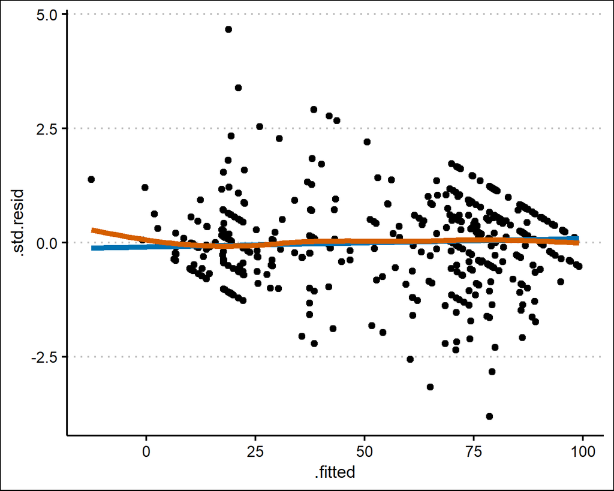

```r
ggplot(data = df_residuals,
       aes(x = `.fitted`,
           y = `.std.resid`)) +
  geom_point() +
  geom_smooth(method = "lm",
              se = FALSE,
              linewidth = 1.5,
              color = "#0072B2") +
  geom_smooth(method = "loess",
              se = FALSE,
              linewidth = 1.5,
              color = "#D55E00") +
  theme_clean()
```

We should then also examine scatterplots of the residuals against the L1 predictors.

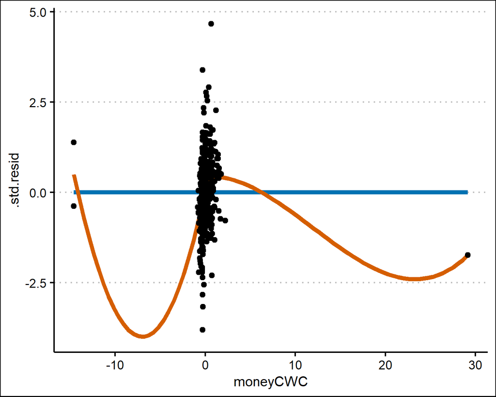

```r
ggplot(data = df_residuals,
       aes(x = moneyCWC,
           y = `.std.resid`)) +
  geom_smooth(method = "lm",
              se = FALSE,
              linewidth = 1.5,
              color = "#0072B2") +
  geom_smooth(method = "loess",
              se = FALSE,
              linewidth = 1.5,
              color = "#D55E00") +
  geom_point() +
  theme_clean()
```

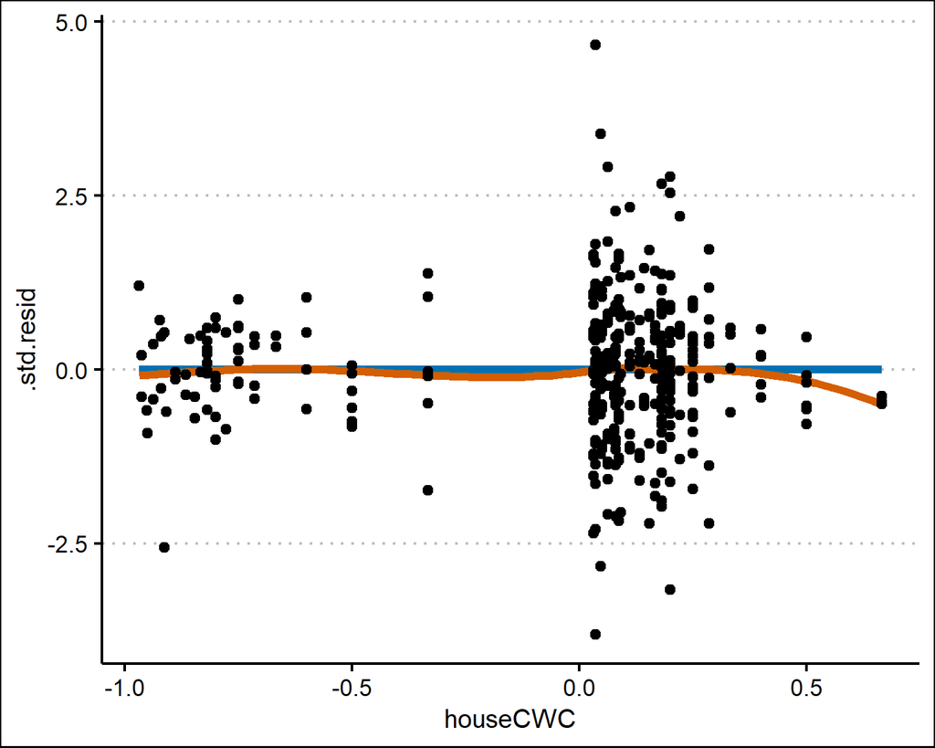

```r
ggplot(data = df_residuals,
       aes(x = houseCWC,
           y = `.std.resid`)) +
  geom_smooth(method = "lm",
              se = FALSE,
              linewidth = 1.5,
              color = "#0072B2") +
  geom_smooth(method = "loess",
              se = FALSE,
              linewidth = 1.5,
              color = "#D55E00") +
  geom_point() +
  theme_clean()
```

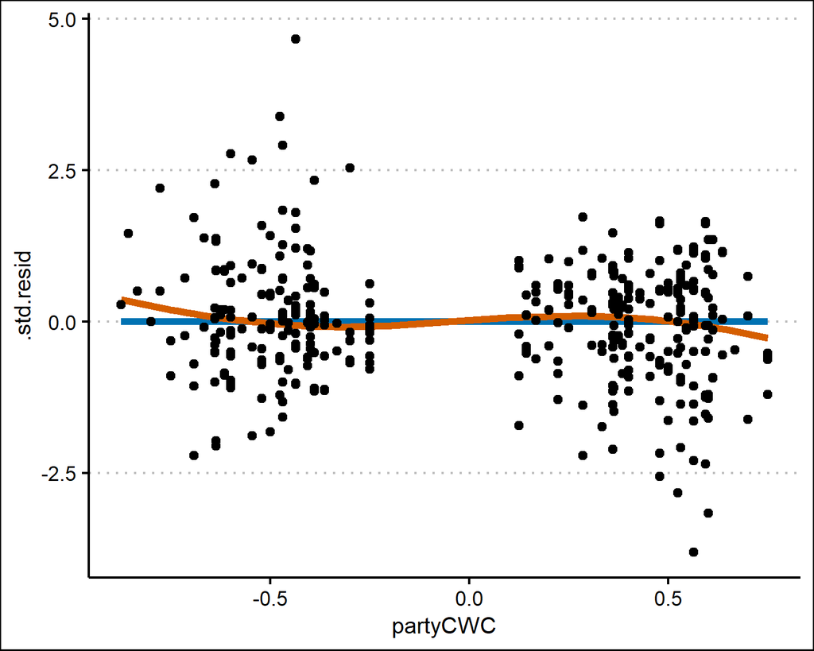

```r
ggplot(data = df_residuals,
       aes(x = partyCWC,
           y = `.std.resid`)) +
  geom_smooth(method = "lm",
              se = FALSE,
              linewidth = 1.5,
              color = "#0072B2") +
  geom_smooth(method = "loess",
              se = FALSE,
              linewidth = 1.5,
              color = "#D55E00") +
  geom_point() +
  theme_clean()
```

### 3.2.2 Homogeneity of variances across groups

You can start here as well by engaging in a few graphical examinations.

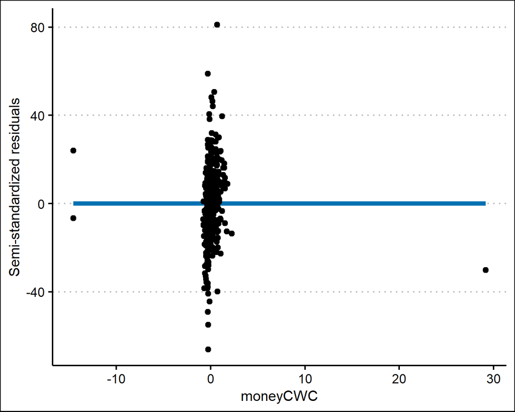

```r
df_residuals <- hlm_resid(mlm.4,
                          level = 1,
                          standardize = "semi",
                          include.ls = FALSE)

ggplot(data = df_residuals,
       aes(x = moneyCWC,
           y = `.resid`)) +
  geom_smooth(method = "lm",
              se = FALSE,
              linewidth = 1.5,
              color = "#0072B2") +
  geom_point() +
  theme_clean() +
  labs(y = "Semi-standardized residuals")
```

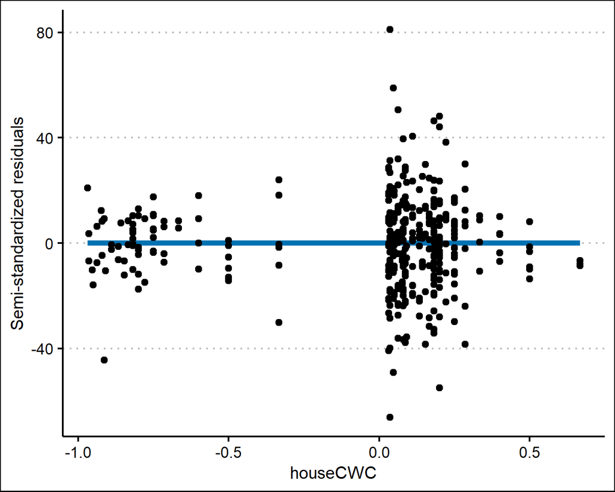

```r
ggplot(data = df_residuals,
       aes(x = houseCWC,
           y = `.resid`)) +
  geom_smooth(method = "lm",
              se = FALSE,
              linewidth = 1.5,
              color = "#0072B2") +
  geom_point() +
  theme_clean() +
  labs(y = "Semi-standardized residuals")
```

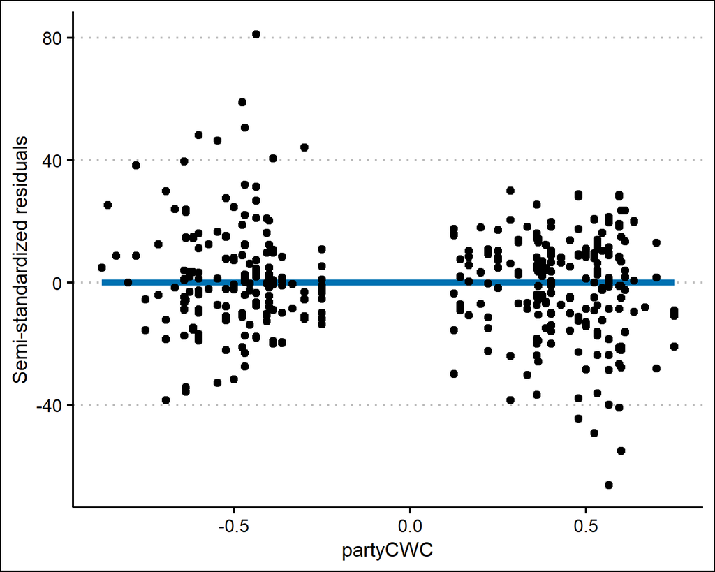

```r
ggplot(data = df_residuals,
       aes(x = partyCWC,
           y = `.resid`)) +
  geom_smooth(method = "lm",
              se = FALSE,
              linewidth = 1.5,
              color = "#0072B2") +
  geom_point() +
  theme_clean() +
  labs(y = "Semi-standardized residuals")
```

### 3.2.3 Normality of errors

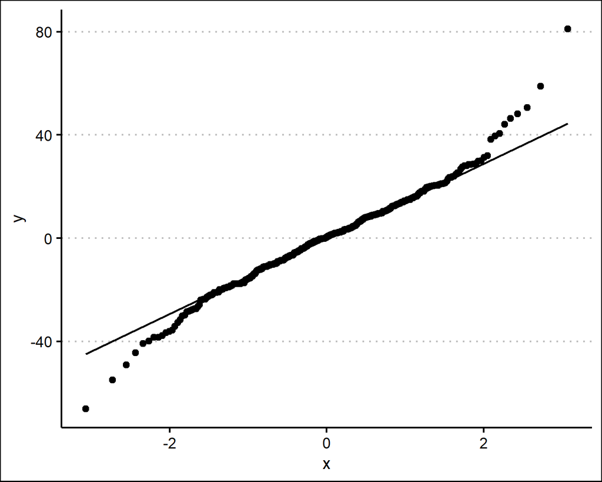

```r
ggplot(data = df_residuals,
       aes(sample = `.resid`)) +
  geom_qq() +
  geom_qq_line() +
  theme_clean()
```

### 3.2.4 Problematic cases

What are the cases that seem most problematic after this round of checks?

```r
df_residuals %>%
    filter(`.resid` > 35 | `.resid` < -35) %>%
    dplyr::select(state, pct100, moneyCWC, partyCWC, houseCWC, logacresCGM) %>%
    kable(digits = 2,
          caption = "Problematic cases based on L1 residuals inspection",
          caption.above = TRUE) %>%
    kable_styling(full_width = TRUE)
```

Problematic cases based on L1 residuals inspection

| state | pct100 | moneyCWC | partyCWC | houseCWC | logacresCGM |
| --- | --- | --- | --- | --- | --- |
| AL | 88.89 | -0.12 | -0.78 | 0.22 | -0.28 |
| CA | 100.00 | 0.67 | -0.44 | 0.04 | -0.28 |
| CA | 40.00 | 0.74 | 0.56 | 0.04 | -0.28 |
| CA | 12.50 | -0.28 | 0.56 | 0.04 | -0.28 |
| FL | 70.00 | 1.22 | -0.64 | 0.08 | 0.37 |
| FL | 37.50 | -0.33 | 0.36 | 0.08 | 0.37 |
| GA | 0.00 | -0.69 | -0.69 | 0.15 | 0.91 |
| IA | 30.00 | -0.34 | 0.29 | 0.29 | -0.28 |
| IL | 80.00 | -0.31 | -0.48 | 0.05 | -0.28 |
| IL | 30.00 | -0.29 | 0.52 | 0.05 | -0.28 |
| IN | 0.00 | -0.45 | -0.64 | 0.09 | 0.40 |
| LA | 90.00 | 0.09 | -0.60 | 0.20 | -0.28 |
| MD | 10.00 | -0.26 | 0.60 | 0.20 | 0.40 |
| MI | 60.00 | -0.16 | -0.39 | 0.11 | -0.28 |
| MN | 70.00 | 0.23 | -0.30 | 0.20 | -0.28 |
| MO | 90.00 | 0.18 | -0.55 | 0.18 | 0.12 |
| NY | 30.00 | -0.28 | 0.59 | 0.03 | -0.28 |
| PA | 16.00 | -0.12 | 0.48 | -0.91 | 0.39 |
| PA | 33.33 | -0.31 | 0.48 | 0.09 | 0.39 |
| TX | 50.00 | -0.31 | 0.53 | 0.06 | -0.28 |
| TX | 88.89 | 0.39 | -0.47 | 0.06 | -0.28 |

## 3.3 L2 residuals

We can do the same types of plots for the Level 2 residuals.

```r
df_residuals <- hlm_resid(mlm.4,
                          level = "state")
df_residuals %<>%
    mutate(state = str_trim(state))
```

### 3.3.1 Normality of errors

We try to find residuals that are outliers.

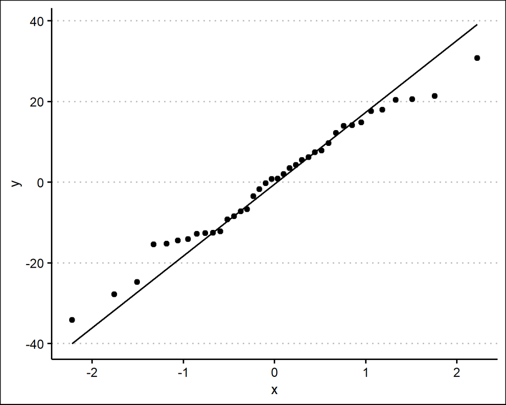

```r
ggplot(data = df_residuals,
       aes(sample = `.ranef.intercept`)) +
  geom_qq() +
  geom_qq_line() +
  theme_clean()
```

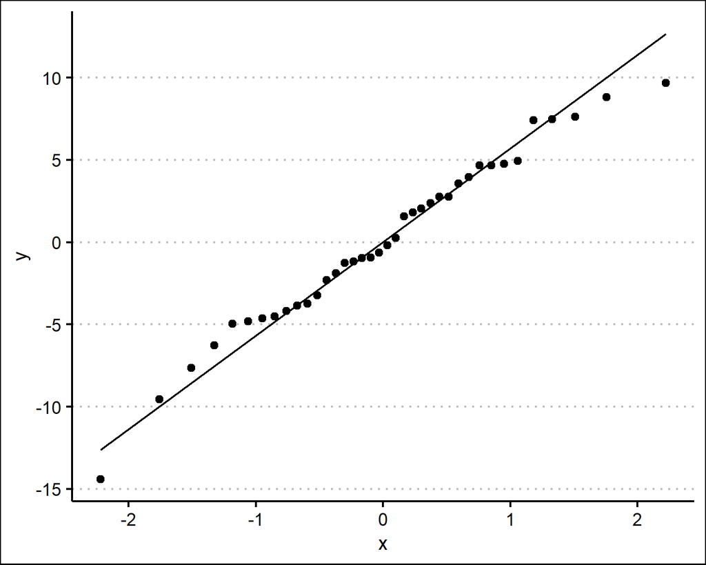

```r
ggplot(data = df_residuals,
       aes(sample = `.ranef.party_cwc`)) +
  geom_qq() +
  geom_qq_line() +
  theme_clean()
```

I don’t want to make this code file unnecessarily long, so I’ll stop here. In a standard analysis for your own work, though, you would go through the same steps as for Level 1 residuals:

1. Linearity
2. Constant variance of residuals

You would use the same kinds of plots as in the previous subsection, but using L2 predictors.